# NOAA Storm Data Analysis

TaylorBurrows

September 3, 2016

# Analysis of NOAA data to assess the health and economic impacts of severe storms in the United States

Author: Taylor Burrows (09/03/2016)

### 1. Description of Assignment

The basic goal of this assignment is to explore the NOAA Storm Database and answer some basic questions about severe weather events. You must use the database to answer the questions below and show the code for your entire analysis. Your analysis can consist of tables, figures, or other summaries. You may use any R package you want to support your analysis. Source: Coursera Assignment Description

### 2. Synopsis

NOAA is the National Oceanic and Atmospheric Administration in the United States. They aim to provide accurate data and cutting edge research in their field. Today we are looking at a public dataset that maintains weather data per storm event dating back over 50 years. These data can show us which weather events have occurred and what implications these events can have on the safety and well being of the surrounding communities. We can see the damage to property, people, and crops, all organized by storm event type.

As you’ll see in these data analyzed below, there were some events that proved to be more dangerous than others. The weather event that causes the most harm to public health is Tornadoes. They have shown in the graphs above to be the largest cause of fatalities and injuries due to weather events in the United States. When strictly talking about economic damages, the events that have caused the most damage are Flood, Drought and Hurricane, but for different reasons. For example the biggest risk to crops is a drought event, whereas the biggest threat to properties are floods.

### 3. Data Processing

##### Set-up

Set working directory and load necessary packages for downstream analysis.

##### 3.1 Load file and look at data

```r
setwd("~/datasciencecoursera/3Reproducible Research/Project2")

if(!file.exists("./NOAA_Data")) {
  dir.create("./NOAA_Data")
}
    fileUrl<-"https://d396qusza40orc.cloudfront.net/repdata%2Fdata%2FStormData.bz2"
    download.file(fileUrl,destfile = "./NOAA_Data/NOAA_Storm_Data.csv", method="curl")
    bunzip2("./NOAA_Data/NOAA_Storm_Data.bz2", exdir="./NOAA_Storm_Data.csv")

NOAA<-read.csv("NOAA_Storm_Data.csv")
```

##### 3.2. Narrow data down by subsetting and reducing

```r
data_col <- c("EVTYPE", "FATALITIES", "INJURIES", "PROPDMG", "PROPDMGEXP", "CROPDMG",
    "CROPDMGEXP")
NOAA_Data<- NOAA[data_col]
```

##### 3.3. Clean up data set and prepare data for analysis

Prepare property damage data and crop data to allow exponents to show correctly in your tidy data set and figures.

Property Exponents

```r
NOAA_Data$PROPEXP[NOAA_Data$PROPDMGEXP == "K"] <- 1000
NOAA_Data$PROPEXP[NOAA_Data$PROPDMGEXP == "M"] <- 1e+06
NOAA_Data$PROPEXP[NOAA_Data$PROPDMGEXP == ""] <- 1
NOAA_Data$PROPEXP[NOAA_Data$PROPDMGEXP == "B"] <- 1e+09
NOAA_Data$PROPEXP[NOAA_Data$PROPDMGEXP == "m"] <- 1e+06
NOAA_Data$PROPEXP[NOAA_Data$PROPDMGEXP == "0"] <- 1
NOAA_Data$PROPEXP[NOAA_Data$PROPDMGEXP == "5"] <- 1e+05
NOAA_Data$PROPEXP[NOAA_Data$PROPDMGEXP == "6"] <- 1e+06
NOAA_Data$PROPEXP[NOAA_Data$PROPDMGEXP == "4"] <- 10000
NOAA_Data$PROPEXP[NOAA_Data$PROPDMGEXP == "2"] <- 100
NOAA_Data$PROPEXP[NOAA_Data$PROPDMGEXP == "3"] <- 1000
NOAA_Data$PROPEXP[NOAA_Data$PROPDMGEXP == "h"] <- 100
NOAA_Data$PROPEXP[NOAA_Data$PROPDMGEXP == "7"] <- 1e+07
NOAA_Data$PROPEXP[NOAA_Data$PROPDMGEXP == "H"] <- 100
NOAA_Data$PROPEXP[NOAA_Data$PROPDMGEXP == "1"] <- 10
NOAA_Data$PROPEXP[NOAA_Data$PROPDMGEXP == "8"] <- 1e+08

NOAA_Data$PROPEXP[NOAA_Data$PROPDMGEXP == "+"] <- 0
NOAA_Data$PROPEXP[NOAA_Data$PROPDMGEXP == "-"] <- 0
NOAA_Data$PROPEXP[NOAA_Data$PROPDMGEXP == "?"] <- 0

NOAA_Data$PROPDMGVAL <- NOAA_Data$PROPDMG * NOAA_Data$PROPEXP
```

Crop Exponents

```r
NOAA_Data$CROPEXP[NOAA_Data$CROPDMGEXP == "M"] <- 1e+06
NOAA_Data$CROPEXP[NOAA_Data$CROPDMGEXP == "K"] <- 1000
NOAA_Data$CROPEXP[NOAA_Data$CROPDMGEXP == "m"] <- 1e+06
NOAA_Data$CROPEXP[NOAA_Data$CROPDMGEXP == "B"] <- 1e+09
NOAA_Data$CROPEXP[NOAA_Data$CROPDMGEXP == "0"] <- 1
NOAA_Data$CROPEXP[NOAA_Data$CROPDMGEXP == "k"] <- 1000
NOAA_Data$CROPEXP[NOAA_Data$CROPDMGEXP == "2"] <- 100
NOAA_Data$CROPEXP[NOAA_Data$CROPDMGEXP == ""] <- 1
NOAA_Data$CROPEXP[NOAA_Data$CROPDMGEXP == "?"] <- 0
NOAA_Data$CROPDMGVAL <- NOAA_Data$CROPDMG * NOAA_Data$CROPEXP
```

##### 3.4. Organize data so that it can be combined and aggregated

Organize by event that we are capturing in results

```r
fatalities <- aggregate(FATALITIES ~ EVTYPE, data = NOAA_Data, FUN = sum)
injuries<- aggregate(INJURIES ~ EVTYPE, data = NOAA_Data, FUN = sum)
prop_dam <- aggregate(PROPDMGVAL ~ EVTYPE, data = NOAA_Data, FUN = sum)
crop_dam <- aggregate(CROPDMGVAL ~ EVTYPE, data = NOAA_Data, FUN = sum)
```

##### 3.5. Obtain top 10 for each category

The data set includes a lot of data, narrowing it down will aid in the analysis

Top 10 Public Health

```r
fatalities_10 <- fatalities[order(-fatalities$FATALITIES), ][1:10, ]
injuries_10 <- injuries[order(-injuries$INJURIES), ][1:10, ]
```

Top 10 Economic

```r
prop_dam10 <- prop_dam[order(-prop_dam$PROPDMGVAL), ][1:10, ]
crop_dam10 <- crop_dam[order(-crop_dam$CROPDMGVAL), ][1:10, ]
```

### 4. Results

##### 4.1. Question 1

1. Across the United States, which types of events (as indicated in the EVTYPE variable) are most harmful with respect to population health?

Injuries versus Fatalities —> create the plot

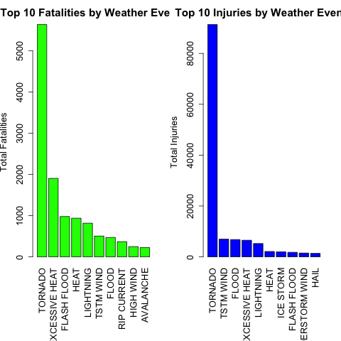

```r
par(mfrow = c(1, 2), mar = c(10, 4, 3, 2), mgp = c(3, 1, 0), cex = 0.8)
barplot(fatalities_10$FATALITIES, las = 3, names.arg = fatalities_10$EVTYPE, main = "Top 10 Fatalities by Weather Events",
    ylab = "Total Fatalities", col = "green")
barplot(injuries_10$INJURIES, las = 3, names.arg = injuries_10$EVTYPE, main = "Top 10 Injuries by Weather Events",
    ylab = "Total Injuries", col = "blue")

dev.copy(png,file="barplot1.png")
dev.off()
```

Conclusion: The weather event that causes the most harm to public health is Tornadoes. They have shown in the graphs above to be the largest cause of fatalities and injuries due to weather events in the United States.

##### 4.2. Question 2

2. Across the United States, which types of events have the greatest economic consequences?

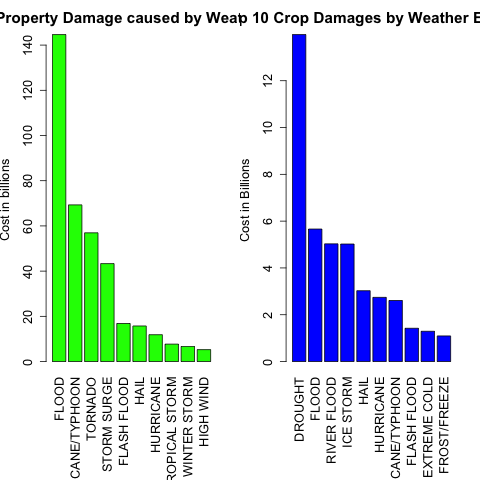

```r
par(mfrow = c(1, 2), mar = c(10, 4, 3, 2), mgp = c(3, 1, 0), cex = 0.8)
barplot(prop_dam10$PROPDMGVAL/(10^9), las = 3, names.arg = prop_dam10$EVTYPE,
    main = "Top 10 Property Damage caused by Weather Events", ylab = "Cost in billions",
    col = "green")
barplot(crop_dam10$CROPDMGVAL/(10^9), las = 3, names.arg = crop_dam10$EVTYPE,
    main = "Top 10 Crop Damages by Weather Events", ylab = "Cost in Billions",
    col = "blue")

dev.copy(png,file="barplot2.png")
dev.off()
```

Conclusion: The events that have caused the most damage in the United states from an economic stand point are Flood, Drought and Hurricane, but for different reasons. For example the biggest risk to crops is a drougth event, whereas the biggest threat to properties are floods.